# Intro to Bayesian Topics in 30 min

Krum Arnaudov  
2021-11-20 (updated: 2021-11-21)

### What's the Bayesian Hype About?

- **Rethinking of statistical ideas**:
  - Use *probability* to describe uncertainty/risk
  - Ability to incorporate institutional knowledge
  - Increased modeling flexibility

**+**

- **Hardware and Software advances**:
  - Faster CPUs
  - Successes in moving computations to GPUs

**+**

- **Increasing industry success stories:**
  - Facebook (time series forecasting)
  - Uber (churn)
  - Baker Hughes (preventive maintenance)

## Bayesian Data Analysis TLDR

Count all the ways data can happen, according to assumptions.

Assumptions with more ways that are consistent with data are more plausible.

## Sounds easy, eh?

### Bayesian Terminology

## Everything is a distribution!

- Priors, Likelihoods and Posteriors.
  - Conjugate priors ??
  - Updating ??

## Monte Carlo Markov Chains

- Chains !?

## Some similar but different terms:

- Credible Intervals
- ROPE (Region of Practical Equivalence) - significance testing
- PD (Probability of Direction)
- Bayes Factor - hypothesis testing

### We want to know

- How many visitors/clicks will we get out of a 100 shown adds.
- Will we get more than 5 clicks/visitors?

### Let us simulate data

```r
n_visitors <- rbinom(
  # Simulate 100K times
  n = 100000,
  # Number of total page views
  size = 100,
  # Probability of click
  prob = 0.1
)

mean(n_visitors > 5)
```

```
[1] 0.94224
```

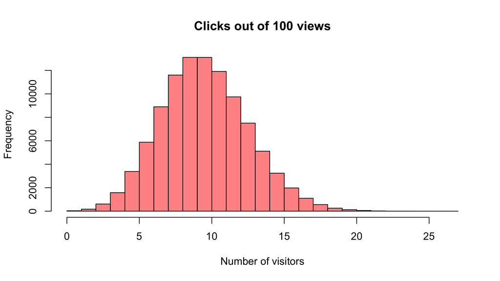

### So Far

- Represented uncertainty over future data with probability
- Worked with samples

```r
n_visitors <- rbinom(
  n = 100000,
  size = 100,
  prob = 0.1
)

mean(n_visitors > 5)
```

```
[1] 0.94254
```

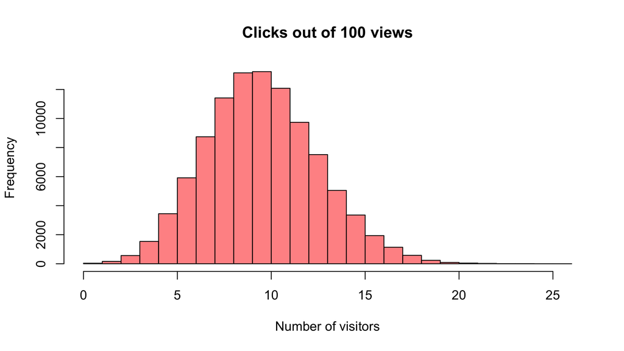

```r
proportion_clicks <- runif(
 n = 100000,
 min = 0.0,
 max = 0.2)
```

```r
n_visitors <- rbinom(
  n = 100000,
  size = 100,
  prob = 0.1
)
```

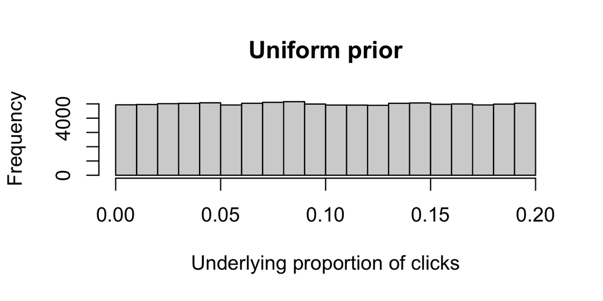

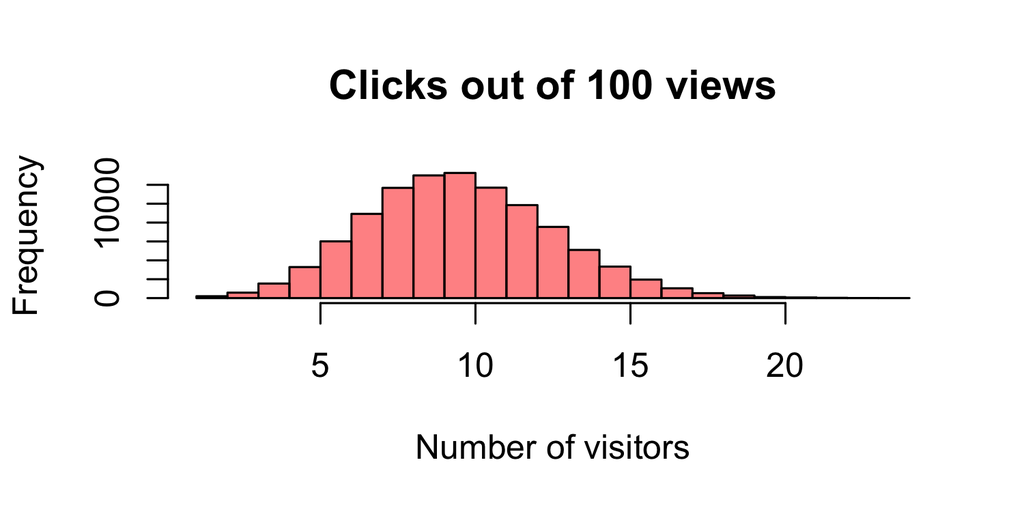

```r
proportion_clicks <- runif(
 n = 100000,
 min = 0.0,
 max = 0.2)
```

```r
n_visitors <- rbinom(
  n = 100000,
  size = 100,
  prob = proportion_clicks
)
```

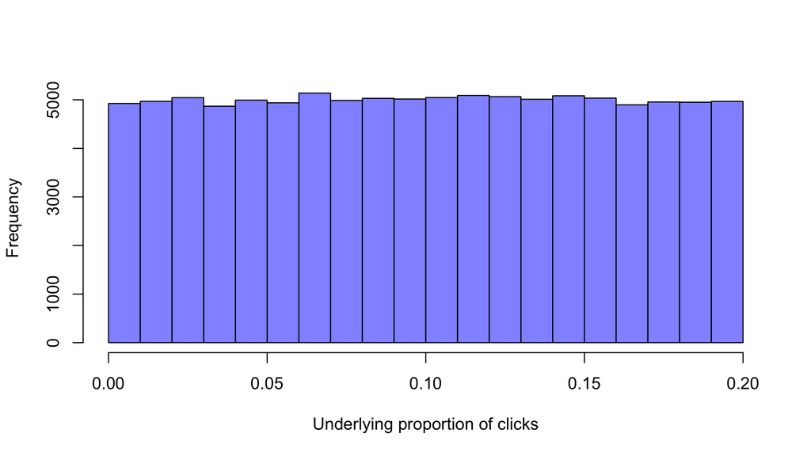

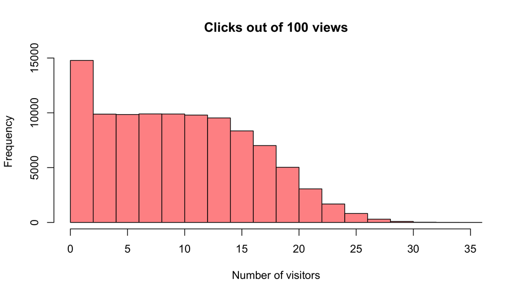

```r
proportion_clicks <- runif(
 n = 100000,
 min = 0.0,
 max = 0.2)
```

```r
n_visitors <- rbinom(
  n = 100000,
  size = 100,
  prob = proportion_clicks
)
```

```r
mean(n_visitors > 5)
```

```
[1] 0.70413
```

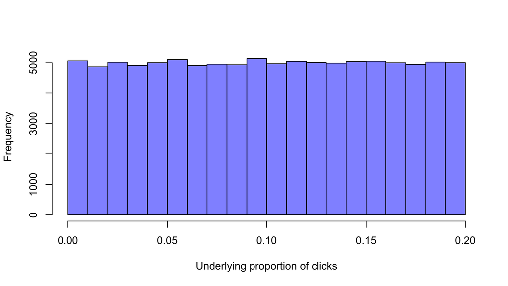

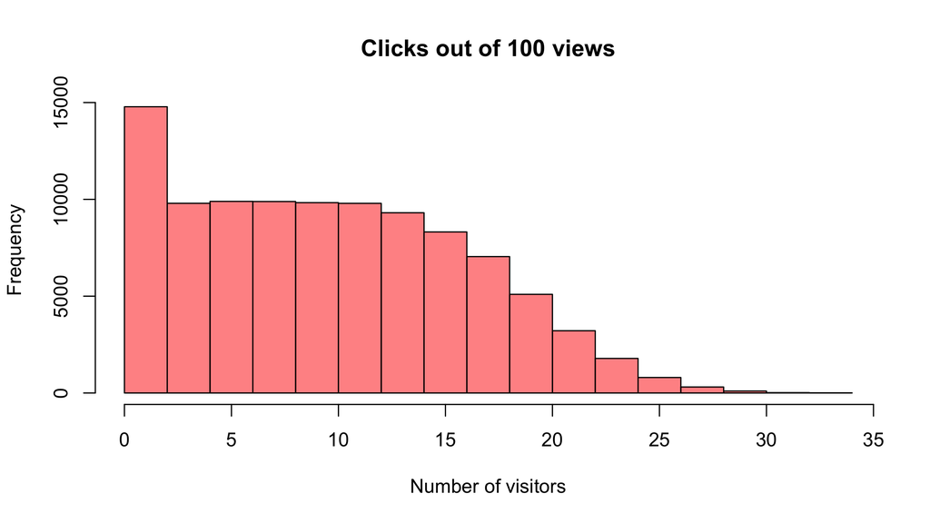

### So Far

- Represented uncertainty over future data with probability
- Worked with samples
- Represented prior uncertainty over parameters with probability
- Produced a prior predictive distribution over future data

```r
prior <- data.frame(n_visitors, proportion_clicks)
```

```r
head(prior)
```

```
  n_visitors proportion_clicks
1          9        0.07200833
2          4        0.04523047
3          4        0.03245836
4          5        0.05146508
5         13        0.11564031
6         12        0.09898077
```

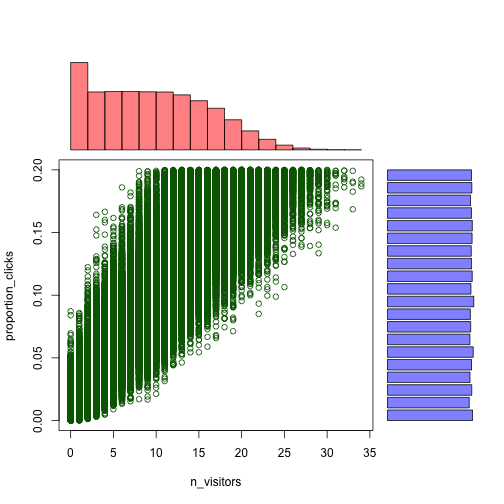

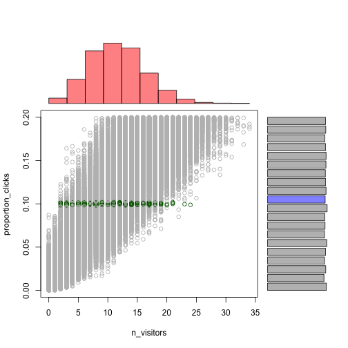

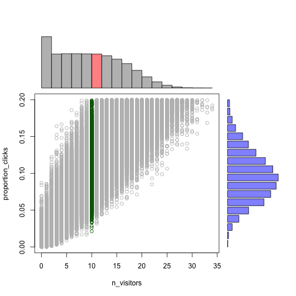

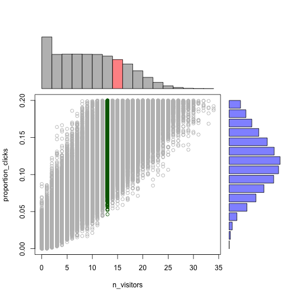

```r
plot(prior)
```

```r
prior <- data.frame(proportion_clicks, n_visitors)

posterior <- prior[prior$n_visitors ==13, ]
```

```r
hist(posterior$proportion_clicks)
```

```r
n_visitors <- rbinom(
 n = 100000,
 size = 100,
 prob = posterior$proportion_clicks)

mean(n_visitors > 5)
```

```
[1] 0.97111
```

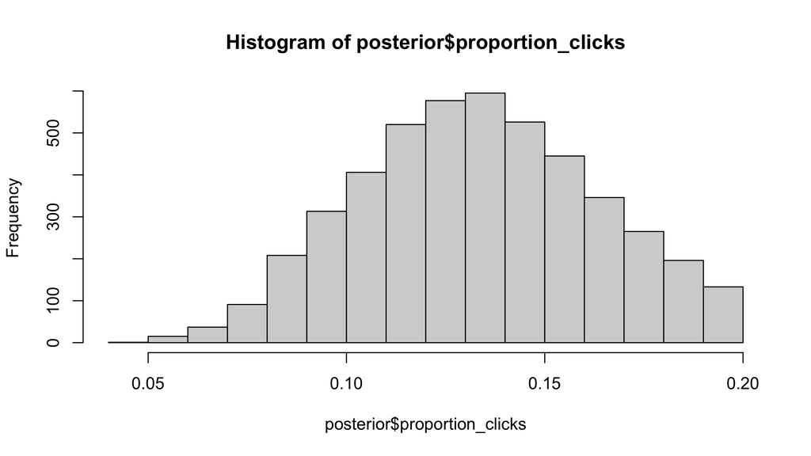

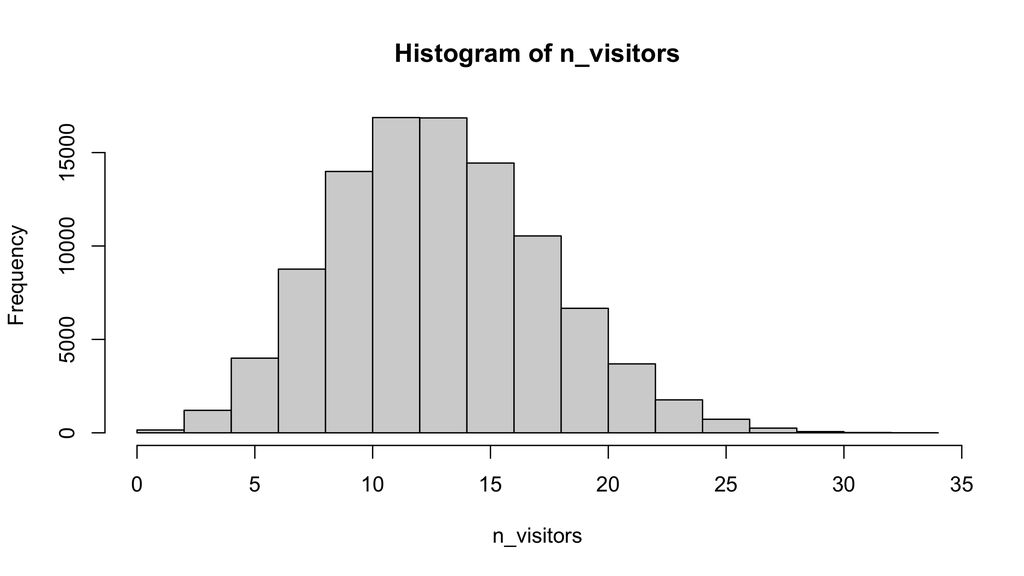

### So Far

- Represented uncertainty over future data with probability
- Worked with samples
- Represented prior uncertainty over parameters with probability
- Produced a prior predictive distribution over future data
- Bayesian inference by conditioning on the data
- Produced a posterior predictive distribution